# Abstract

This sample demonstrates *Data Preprocessing* and *Exploratory Data Analysis (EDA)* using a dataset of Titanic passengers.

**Data Preprocessing** is necessary to prepare raw data for analysis and use by machine learning models. Estimates predict that this task is responsible for 60-80% of the total time spent building machine learning models. Some common subtasks include:

- Checking for inconsistencies
- Handling missing values
- Handling outliers
- Removing duplicate data

**Exploratory Data Analysis (EDA)** is used to learn more about the data, allowing one to understand and best optimize it for a machine learning model. Some common subtasks include:

- Finding relationships between features
- Identifying errors
- Observing patterns

# Objective

Perform **data preprocessing** and **exploratory data analysis** tasks on the Titanic dataset.

The ultimate goal is to create a model that will predict whether a passenger on the Titanic would have survived or not.

# Data Dictionary

- **`survival`** - If the passenger survived (0=no, 1=yes)
- **`pclass`** - The passenger's class (1=1st, 2=2nd, 3=3rd)
- **`name`** - The passenger's name
- **`sex`** - The passenger's sex
- **`age`** - The passenger's age
- **`sibsp`** - The number of siblings/spouses aboard with the passenger
- **`parch`** - The number of parents/children aboard with the passenger
- **`ticket`** - The passenger's ticket number
- **`fare`** - The passenger's ticket fare in British pounds
- **`cabin`** - The passenger's cabin
- **`embarked`** - The port that the passenger embarked from (C=Cherbourg, Q=Queenstown, S=Southampton)

# Data Overview

```python
# import necessary libraries
import pandas as pd
import numpy as np
import seaborn as sns
import matplotlib.pyplot as plt
```

```python
# load csv into dataframe
df = pd.read_csv("titanic_passenger_list.csv")
```

```python
# view the first 10 rows of the dataframe
df.head(10)
```

|  | pclass | survived | name | sex | age | sibsp | parch | ticket | fare | cabin | embarked | boat | body | home.dest |
| --- | --- | --- | --- | --- | --- | --- | --- | --- | --- | --- | --- | --- | --- | --- |
| 0 | 1 | 1 | Allen, Miss. Elisabeth Walton | female | 29.00 | 0 | 0 | 24160 | 211.3375 | B5 | S | 2 | NaN | St Louis, MO |
| 1 | 1 | 1 | Allison, Master. Hudson Trevor | male | 0.92 | 1 | 2 | 113781 | 151.5500 | C22 C26 | S | 11 | NaN | Montreal, PQ / Chesterville, ON |
| 2 | 1 | 0 | Allison, Miss. Helen Loraine | female | 2.00 | 1 | 2 | 113781 | 151.5500 | C22 C26 | S | NaN | NaN | Montreal, PQ / Chesterville, ON |
| 3 | 1 | 0 | Allison, Mr. Hudson Joshua Creighton | male | 30.00 | 1 | 2 | 113781 | 151.5500 | C22 C26 | S | NaN | 135.0 | Montreal, PQ / Chesterville, ON |
| 4 | 1 | 0 | Allison, Mrs. Hudson J C (Bessie Waldo Daniels) | female | 25.00 | 1 | 2 | 113781 | 151.5500 | C22 C26 | S | NaN | NaN | Montreal, PQ / Chesterville, ON |
| 5 | 1 | 1 | Anderson, Mr. Harry | male | 48.00 | 0 | 0 | 19952 | 26.5500 | E12 | S | 3 | NaN | New York, NY |
| 6 | 1 | 1 | Andrews, Miss. Kornelia Theodosia | female | 63.00 | 1 | 0 | 13502 | 77.9583 | D7 | S | 10 | NaN | Hudson, NY |
| 7 | 1 | 0 | Andrews, Mr. Thomas Jr | male | 39.00 | 0 | 0 | 112050 | 0.0000 | A36 | S | NaN | NaN | Belfast, NI |
| 8 | 1 | 1 | Appleton, Mrs. Edward Dale (Charlotte Lamson) | female | 53.00 | 2 | 0 | 11769 | 51.4792 | C101 | S | D | NaN | Bayside, Queens, NY |
| 9 | 1 | 0 | Artagaveytia, Mr. Ramon | male | 71.00 | 0 | 0 | PC 17609 | 49.5042 | NaN | C | NaN | 22.0 | Montevideo, Uruguay |

```python
# view a 10 row sample of the dataframe
df.sample(10)
```

|  | pclass | survived | name | sex | age | sibsp | parch | ticket | fare | cabin | embarked | boat | body | home.dest |
| --- | --- | --- | --- | --- | --- | --- | --- | --- | --- | --- | --- | --- | --- | --- |
| 915 | 3 | 0 | Karlsson, Mr. Nils August | male | 22.0 | 0 | 0 | 350060 | 7.5208 | NaN | S | NaN | NaN | NaN |
| 753 | 3 | 0 | Davies, Mr. Evan | male | 22.0 | 0 | 0 | SC/A4 23568 | 8.0500 | NaN | S | NaN | NaN | NaN |
| 1272 | 3 | 0 | Vander Cruyssen, Mr. Victor | male | 47.0 | 0 | 0 | 345765 | 9.0000 | NaN | S | NaN | NaN | NaN |
| 203 | 1 | 0 | Meyer, Mr. Edgar Joseph | male | 28.0 | 1 | 0 | PC 17604 | 82.1708 | NaN | C | NaN | NaN | New York, NY |
| 333 | 2 | 1 | Ball, Mrs. (Ada E Hall) | female | 36.0 | 0 | 0 | 28551 | 13.0000 | D | S | 10 | NaN | Bristol, Avon / Jacksonville, FL |
| 363 | 2 | 0 | Campbell, Mr. William | male | NaN | 0 | 0 | 239853 | 0.0000 | NaN | S | NaN | NaN | Belfast |
| 391 | 2 | 0 | del Carlo, Mr. Sebastiano | male | 29.0 | 1 | 0 | SC/PARIS 2167 | 27.7208 | NaN | C | NaN | 295.0 | Lucca, Italy / California |
| 257 | 1 | 1 | Schabert, Mrs. Paul (Emma Mock) | female | 35.0 | 1 | 0 | 13236 | 57.7500 | C28 | C | 11 | NaN | New York, NY |
| 450 | 2 | 0 | Hodges, Mr. Henry Price | male | 50.0 | 0 | 0 | 250643 | 13.0000 | NaN | S | NaN | 149.0 | Southampton |
| 582 | 2 | 1 | Watt, Miss. Bertha J | female | 12.0 | 0 | 0 | C.A. 33595 | 15.7500 | NaN | S | 9 | NaN | Aberdeen / Portland, OR |

```python
# use .shape to determine how many rows and columns are in the dataframe
df.shape
```

```
(1309, 14)
```

```python
# check for duplicate values in the dataframe
df.duplicated().sum()
```

```
np.int64(0)
```

```python
# information on all columns in the dataframe
df.info()
```

```
<class 'pandas.core.frame.DataFrame'>
RangeIndex: 1309 entries, 0 to 1308
Data columns (total 14 columns):
 #   Column     Non-Null Count  Dtype
---  ------     --------------  -----
 0   pclass     1309 non-null   int64
 1   survived   1309 non-null   int64
 2   name       1309 non-null   object
 3   sex        1309 non-null   object
 4   age        1046 non-null   float64
 5   sibsp      1309 non-null   int64
 6   parch      1309 non-null   int64
 7   ticket     1309 non-null   object
 8   fare       1308 non-null   float64
 9   cabin      295 non-null    object
 10  embarked   1307 non-null   object
 11  boat       486 non-null    object
 12  body       121 non-null    float64
 13  home.dest  745 non-null    object
dtypes: float64(3), int64(4), object(7)
memory usage: 143.3+ KB
```

```python
# find the data type of each column
df.dtypes
```

```
pclass         int64
survived       int64
name          object
sex           object
age          float64
sibsp          int64
parch          int64
ticket        object
fare         float64
cabin         object
embarked      object
boat          object
body         float64
home.dest     object
dtype: object
```

```python
# find the number of non-null values for each column
df.count()
```

```
pclass       1309
survived     1309
name         1309
sex          1309
age          1046
sibsp        1309
parch        1309
ticket       1309
fare         1308
cabin         295
embarked     1307
boat          486
body          121
home.dest     745
dtype: int64
```

```python
# find the number of null values for each row
df.isna().sum()
```

```
pclass          0
survived        0
name            0
sex             0
age           263
sibsp           0
parch           0
ticket          0
fare            1
cabin        1014
embarked        2
boat          823
body         1188
home.dest     564
dtype: int64
```

```python
# find statistical information for the numeric columns
df.describe()
```

|  | pclass | survived | age | sibsp | parch | fare | body |
| --- | --- | --- | --- | --- | --- | --- | --- |
| count | 1309.000000 | 1309.000000 | 1046.000000 | 1309.000000 | 1309.000000 | 1308.000000 | 121.000000 |
| mean | 2.294882 | 0.381971 | 29.881138 | 0.498854 | 0.385027 | 33.295479 | 160.809917 |
| std | 0.837836 | 0.486055 | 14.413493 | 1.041658 | 0.865560 | 51.758668 | 97.696922 |
| min | 1.000000 | 0.000000 | 0.170000 | 0.000000 | 0.000000 | 0.000000 | 1.000000 |
| 25% | 2.000000 | 0.000000 | 21.000000 | 0.000000 | 0.000000 | 7.895800 | 72.000000 |
| 50% | 3.000000 | 0.000000 | 28.000000 | 0.000000 | 0.000000 | 14.454200 | 155.000000 |
| 75% | 3.000000 | 1.000000 | 39.000000 | 1.000000 | 0.000000 | 31.275000 | 256.000000 |
| max | 3.000000 | 1.000000 | 80.000000 | 8.000000 | 9.000000 | 512.329200 | 328.000000 |

```python
df.describe().T
```

|  | count | mean | std | min | 25% | 50% | 75% | max |
| --- | --- | --- | --- | --- | --- | --- | --- | --- |
| pclass | 1309.0 | 2.294882 | 0.837836 | 1.00 | 2.0000 | 3.0000 | 3.000 | 3.0000 |
| survived | 1309.0 | 0.381971 | 0.486055 | 0.00 | 0.0000 | 0.0000 | 1.000 | 1.0000 |
| age | 1046.0 | 29.881138 | 14.413493 | 0.17 | 21.0000 | 28.0000 | 39.000 | 80.0000 |
| sibsp | 1309.0 | 0.498854 | 1.041658 | 0.00 | 0.0000 | 0.0000 | 1.000 | 8.0000 |
| parch | 1309.0 | 0.385027 | 0.865560 | 0.00 | 0.0000 | 0.0000 | 0.000 | 9.0000 |
| fare | 1308.0 | 33.295479 | 51.758668 | 0.00 | 7.8958 | 14.4542 | 31.275 | 512.3292 |
| body | 121.0 | 160.809917 | 97.696922 | 1.00 | 72.0000 | 155.0000 | 256.000 | 328.0000 |

```python
df.nunique()
```

```
pclass          3
survived        2
name         1307
sex             2
age            98
sibsp           7
parch           8
ticket        929
fare          281
cabin         186
embarked        3
boat           27
body          121
home.dest     369
dtype: int64
```

```python
df['survived'].value_counts()
```

```
survived
0    809
1    500
Name: count, dtype: int64
```

## Observations

- **`age`**, **`fare`**, **`cabin`**, and **`embarked`** have missing values
- **`age`**, **`fare`**, **`sibsp`**, and **`parch`** appear to have outliers that should be looked into

# Data Preprocessing

## Handling missing values

We use the following guidelines to determine how to impute missing values:

- **Numeric values**: use mean is there is a standard distribution and median if the data is skewed
- **Categorical values**: use mode

### **`age`**

```python
df['age'].isna().sum()
```

```
np.int64(263)
```

```python
df.age.describe().T
```

```
count    1046.000000
mean       29.881138
std        14.413493
min         0.170000
25%        21.000000
50%        28.000000
75%        39.000000
max        80.000000
Name: age, dtype: float64
```

```python
df[df['age'].isnull()]
```

|  | pclass | survived | name | sex | age | sibsp | parch | ticket | fare | cabin | embarked | boat | body | home.dest |
| --- | --- | --- | --- | --- | --- | --- | --- | --- | --- | --- | --- | --- | --- | --- |
| 15 | 1 | 0 | Baumann, Mr. John D | male | NaN | 0 | 0 | PC 17318 | 25.9250 | NaN | S | NaN | NaN | New York, NY |
| 37 | 1 | 1 | Bradley, Mr. George ("George Arthur Brayton") | male | NaN | 0 | 0 | 111427 | 26.5500 | NaN | S | 9 | NaN | Los Angeles, CA |
| 40 | 1 | 0 | Brewe, Dr. Arthur Jackson | male | NaN | 0 | 0 | 112379 | 39.6000 | NaN | C | NaN | NaN | Philadelphia, PA |
| 46 | 1 | 0 | Cairns, Mr. Alexander | male | NaN | 0 | 0 | 113798 | 31.0000 | NaN | S | NaN | NaN | NaN |
| 59 | 1 | 1 | Cassebeer, Mrs. Henry Arthur Jr (Eleanor Genev... | female | NaN | 0 | 0 | 17770 | 27.7208 | NaN | C | 5 | NaN | New York, NY |
| ... | ... | ... | ... | ... | ... | ... | ... | ... | ... | ... | ... | ... | ... | ... |
| 1293 | 3 | 0 | Williams, Mr. Howard Hugh "Harry" | male | NaN | 0 | 0 | A/5 2466 | 8.0500 | NaN | S | NaN | NaN | NaN |
| 1297 | 3 | 0 | Wiseman, Mr. Phillippe | male | NaN | 0 | 0 | A/4. 34244 | 7.2500 | NaN | S | NaN | NaN | NaN |
| 1302 | 3 | 0 | Yousif, Mr. Wazli | male | NaN | 0 | 0 | 2647 | 7.2250 | NaN | C | NaN | NaN | NaN |
| 1303 | 3 | 0 | Yousseff, Mr. Gerious | male | NaN | 0 | 0 | 2627 | 14.4583 | NaN | C | NaN | NaN | NaN |
| 1305 | 3 | 0 | Zabour, Miss. Thamine | female | NaN | 1 | 0 | 2665 | 14.4542 | NaN | C | NaN | NaN | NaN |

263 rows × 14 columns

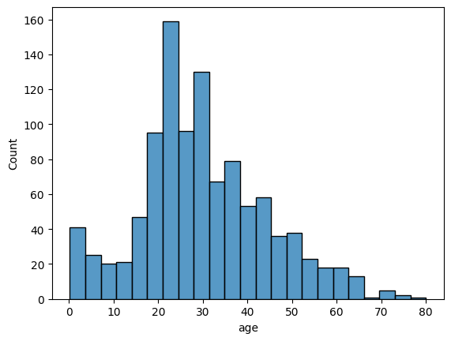

```python
sns.histplot(df['age'])
```

We impute 263 **`age`** values using the mean.

```python
df.loc[df.age.isnull(), 'age'] = 30
# df['age'] = df['age'].replace(np.nan, ??)
```

```python
df.age.isnull().sum()
```

```
np.int64(0)
```

```python
# how did this affect the column's statistics?
df.age.describe().T
```

```
count    1309.000000
mean       29.905019
std        12.883281
min         0.170000
25%        22.000000
50%        30.000000
75%        35.000000
max        80.000000
Name: age, dtype: float64
```

### **`cabin`**

```python
df['cabin'].isnull().sum()
```

```
np.int64(1014)
```

Over 75% of the rows do not have a value for **`cabin`**. With that many values missing, we decide to delete the feature.

```python
df = df.drop(['cabin'], axis=1)
df.sample(10)
```

|  | pclass | survived | name | sex | age | sibsp | parch | ticket | fare | embarked | boat | body | home.dest |
| --- | --- | --- | --- | --- | --- | --- | --- | --- | --- | --- | --- | --- | --- |
| 902 | 3 | 0 | Johnston, Mr. Andrew G | male | 30.0 | 1 | 2 | W./C. 6607 | 23.4500 | S | NaN | NaN | NaN |
| 945 | 3 | 1 | Lam, Mr. Ali | male | 30.0 | 0 | 0 | 1601 | 56.4958 | S | C | NaN | NaN |
| 1196 | 3 | 1 | Sheerlinck, Mr. Jan Baptist | male | 29.0 | 0 | 0 | 345779 | 9.5000 | S | 11 | NaN | NaN |
| 9 | 1 | 0 | Artagaveytia, Mr. Ramon | male | 71.0 | 0 | 0 | PC 17609 | 49.5042 | C | NaN | 22.0 | Montevideo, Uruguay |
| 520 | 2 | 1 | Nourney, Mr. Alfred ("Baron von Drachstedt") | male | 20.0 | 0 | 0 | SC/PARIS 2166 | 13.8625 | C | 7 | NaN | Cologne, Germany |
| 305 | 1 | 0 | Weir, Col. John | male | 60.0 | 0 | 0 | 113800 | 26.5500 | S | NaN | NaN | England Salt Lake City, Utah |
| 1291 | 3 | 0 | Willer, Mr. Aaron ("Abi Weller") | male | 30.0 | 0 | 0 | 3410 | 8.7125 | S | NaN | NaN | NaN |
| 1175 | 3 | 0 | Sage, Miss. Stella Anna | female | 30.0 | 8 | 2 | CA. 2343 | 69.5500 | S | NaN | NaN | NaN |
| 715 | 3 | 0 | Christmann, Mr. Emil | male | 29.0 | 0 | 0 | 343276 | 8.0500 | S | NaN | NaN | NaN |
| 705 | 3 | 0 | Caram, Mr. Joseph | male | 30.0 | 1 | 0 | 2689 | 14.4583 | C | NaN | NaN | Ottawa, ON |

### **`embarked`**

```python
df['embarked'].isnull().sum()
```

```
np.int64(2)
```

```python
df[df['embarked'].isnull()]
```

|  | pclass | survived | name | sex | age | sibsp | parch | ticket | fare | embarked | boat | body | home.dest |
| --- | --- | --- | --- | --- | --- | --- | --- | --- | --- | --- | --- | --- | --- |
| 168 | 1 | 1 | Icard, Miss. Amelie | female | 38.0 | 0 | 0 | 113572 | 80.0 | NaN | 6 | NaN | NaN |
| 284 | 1 | 1 | Stone, Mrs. George Nelson (Martha Evelyn) | female | 62.0 | 0 | 0 | 113572 | 80.0 | NaN | 6 | NaN | Cincinatti, OH |

```python
df['embarked'].mode()
```

```
0    S
Name: embarked, dtype: object
```

```python
df['embarked'].value_counts()
```

```
embarked
S    914
C    270
Q    123
Name: count, dtype: int64
```

We impute 2 missing **`embarked`** values with the mode.

```python
df['embarked'] = df['embarked'].replace(np.nan, 'S')
```

```python
# verify there aren't any missing values
df.isnull().sum()
```

```
pclass          0
survived        0
name            0
sex             0
age             0
sibsp           0
parch           0
ticket          0
fare            1
embarked        0
boat          823
body         1188
home.dest     564
dtype: int64
```

### **`fare`**

```python
df['fare'].isnull().sum()
```

```
np.int64(1)
```

```python
df[df['fare'].isnull()]
```

|  | pclass | survived | name | sex | age | sibsp | parch | ticket | fare | embarked | boat | body | home.dest |
| --- | --- | --- | --- | --- | --- | --- | --- | --- | --- | --- | --- | --- | --- |
| 1225 | 3 | 0 | Storey, Mr. Thomas | male | 60.5 | 0 | 0 | 3701 | NaN | S | NaN | 261.0 | NaN |

```python
df.fare.describe().T
```

```
count    1308.000000
mean       33.295479
std        51.758668
min         0.000000
25%         7.895800
50%        14.454200
75%        31.275000
max       512.329200
Name: fare, dtype: float64
```

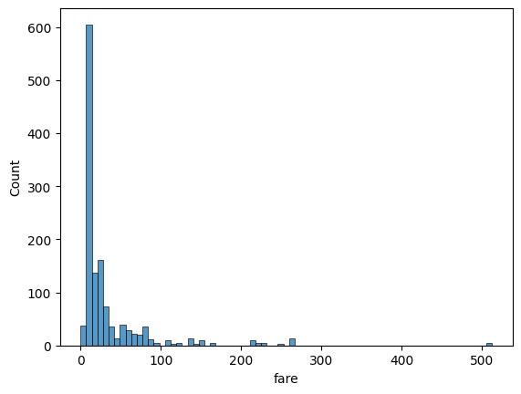

```python
sns.histplot(df['fare'])
```

We impute a missing **`fare`** value with the median.

```python
df.loc[df.fare.isnull(), 'fare'] = df.fare.median()
# df['fare'] = df['fare'].replace(np.nan, df.fare.median())
```

```python
df.fare.describe().T
```

```
count    1309.000000
mean       33.281086
std        51.741500
min         0.000000
25%         7.895800
50%        14.454200
75%        31.275000
max       512.329200
Name: fare, dtype: float64
```

## Examining outliers

```python
df.describe().T
```

|  | count | mean | std | min | 25% | 50% | 75% | max |
| --- | --- | --- | --- | --- | --- | --- | --- | --- |
| pclass | 1309.0 | 2.294882 | 0.837836 | 1.00 | 2.0000 | 3.0000 | 3.000 | 3.0000 |
| survived | 1309.0 | 0.381971 | 0.486055 | 0.00 | 0.0000 | 0.0000 | 1.000 | 1.0000 |
| age | 1309.0 | 29.905019 | 12.883281 | 0.17 | 22.0000 | 30.0000 | 35.000 | 80.0000 |
| sibsp | 1309.0 | 0.498854 | 1.041658 | 0.00 | 0.0000 | 0.0000 | 1.000 | 8.0000 |
| parch | 1309.0 | 0.385027 | 0.865560 | 0.00 | 0.0000 | 0.0000 | 0.000 | 9.0000 |
| fare | 1309.0 | 33.281086 | 51.741500 | 0.00 | 7.8958 | 14.4542 | 31.275 | 512.3292 |
| body | 121.0 | 160.809917 | 97.696922 | 1.00 | 72.0000 | 155.0000 | 256.000 | 328.0000 |

### **`age`**

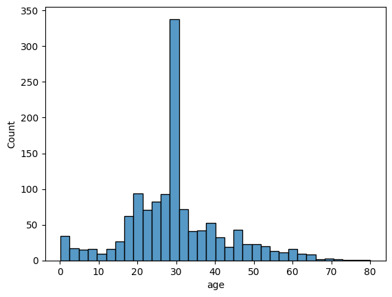

```python
sns.histplot(df['age'])
```

### **`fare`**

```python
df.fare.describe().T
```

```
count    1309.000000
mean       33.281086
std        51.741500
min         0.000000
25%         7.895800
50%        14.454200
75%        31.275000
max       512.329200
Name: fare, dtype: float64
```

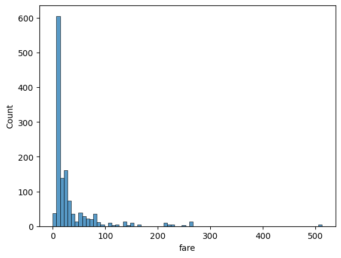

```python
sns.histplot(df['fare'])
```

```python
df[df['fare'] > 500]
```

|  | pclass | survived | name | sex | age | sibsp | parch | ticket | fare | embarked | boat | body | home.dest |
| --- | --- | --- | --- | --- | --- | --- | --- | --- | --- | --- | --- | --- | --- |
| 49 | 1 | 1 | Cardeza, Mr. Thomas Drake Martinez | male | 36.0 | 0 | 1 | PC 17755 | 512.3292 | C | 3 | NaN | Austria-Hungary / Germantown, Philadelphia, PA |
| 50 | 1 | 1 | Cardeza, Mrs. James Warburton Martinez (Charlo... | female | 58.0 | 0 | 1 | PC 17755 | 512.3292 | C | 3 | NaN | Germantown, Philadelphia, PA |
| 183 | 1 | 1 | Lesurer, Mr. Gustave J | male | 35.0 | 0 | 0 | PC 17755 | 512.3292 | C | 3 | NaN | NaN |
| 302 | 1 | 1 | Ward, Miss. Anna | female | 35.0 | 0 | 0 | PC 17755 | 512.3292 | C | 3 | NaN | NaN |

```python
df.groupby("pclass")["fare"].median()
```

```
pclass
1    60.0000
2    15.0458
3     8.0500
Name: fare, dtype: float64
```

```python
# update the 512.3292 fare prices with the median fare price for pclass 1
df.loc[df['fare'] == 512.3292, ['fare']] = 60
```

### **`parch`**

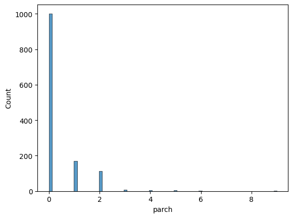

```python
sns.histplot(df['parch'])
```

### **`sibsp`**

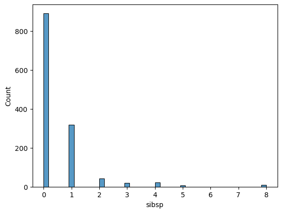

```python
sns.histplot(df['sibsp'])
```

## Checking for inconsistent data

```python
df.dtypes
```

```
pclass         int64
survived       int64
name          object
sex           object
age          float64
sibsp          int64
parch          int64
ticket        object
fare         float64
embarked      object
boat          object
body         float64
home.dest     object
dtype: object
```

### **`embarked`**

```python
df['embarked'].value_counts()
```

```
embarked
S    916
C    270
Q    123
Name: count, dtype: int64
```

### **`parch`**

```python
df['parch'].value_counts()
```

```
parch
0    1002
1     170
2     113
3       8
4       6
5       6
6       2
9       2
Name: count, dtype: int64
```

### **`sex`**

```python
df['sex'].value_counts()
```

```
sex
male      843
female    466
Name: count, dtype: int64
```

### **`sibsp`**

```python
df['sibsp'].value_counts()
```

```
sibsp
0    891
1    319
2     42
4     22
3     20
8      9
5      6
Name: count, dtype: int64
```

## Deleting features that do not affect the prediction

- **`name`**: All but two rows are unique values. At this point we decide to keep them because there are things we may be able to draw out later (e.g., last name, title)
- **`ticket`**: Dropped - no effect on target

```python
df.nunique()
```

```
pclass          3
survived        2
name         1307
sex             2
age            98
sibsp           7
parch           8
ticket        929
fare          280
embarked        3
boat           27
body          121
home.dest     369
dtype: int64
```

```python
df = df.drop(['ticket'], axis=1)
```

# Exploratory Data Analysis

```python
sns.set(color_codes=True)
```

## User functions

```python
def histogram_boxplot(data, feature, figsize=(12, 7), kde=False, bins=None):
    """
    Boxplot and histogram combined

    data: dataframe
    feature: dataframe column
    figsize: size of figure (default (12,7))
    kde: whether to show the density curve (default False)
    bins: number of bins for histogram (default None)
    """
    f2, (ax_box2, ax_hist2) = plt.subplots(
        nrows=2,  # Number of rows of the subplot grid= 2
        sharex=True,  # x-axis will be shared among all subplots
        gridspec_kw={"height_ratios": (0.25, 0.75)},
        figsize=figsize,
    )  # creating the 2 subplots

    sns.boxplot(
        data=data, x=feature, ax=ax_box2, showmeans=True, color="violet"
    )  # boxplot will be created and a star will indicate the mean value of the column

    sns.histplot(
        data=data, x=feature, kde=kde, ax=ax_hist2, bins=bins, palette="winter"
    ) if bins else sns.histplot(
        data=data, x=feature, kde=kde, ax=ax_hist2
    )  # For histogram

    ax_hist2.axvline(
        data[feature].mean(), color="green", linestyle="--"
    )  # Add mean to the histogram

    ax_hist2.axvline(
        data[feature].median(), color="black", linestyle="-"
    )  # Add median to the histogram
```

```python
def labeled_barplot(data, feature, perc=False, n=None):
    """
    Barplot with percentage at the top

    data: dataframe
    feature: dataframe column
    perc: whether to display percentages instead of count (default is False)
    n: displays the top n category levels (default is None, i.e., display all levels)
    """

    total = len(data[feature])  # length of the feature - number of rows
    count = data[feature].nunique() # unique values of the feature
    if n is None:
        plt.figure(figsize=(count + 1, 5))
    else:
        plt.figure(figsize=(n + 1, 5))

    plt.xticks(rotation=90, fontsize=15)
    ax = sns.countplot(
        data=data,
        x=feature,
        palette="Paired",
        hue=feature,
        legend=False,
        order=data[feature].value_counts().index[:n].sort_values(),
    )

    for p in ax.patches:
        if perc == True:
            label = "{:.1f}%".format(
                100 * p.get_height() / total
            )  # percentage of each class of the category
        else:
            label = p.get_height()  # count of each level of the category

        x = p.get_x() + p.get_width() / 2  # width of the plot
        y = p.get_height()  # height of the plot

        ax.annotate(
            label,
            (x, y),
            ha="center",
            va="center",
            size=12,
            xytext=(0, 5),
            textcoords="offset points",
        )  # annotate the percentage

    plt.show()  # show the plot
```

```python
def stacked_barplot(data, predictor, target):
    """
    Print the category counts and plot a stacked bar chart

    data: dataframe
    predictor: independent variable
    target: target variable
    """
    count = data[predictor].nunique() # unique values of the feature
    sorter = data[target].value_counts().index[-1]
    tab1 = pd.crosstab(data[predictor], data[target], margins=True).sort_values(
        by=sorter, ascending=False
    )
    print(tab1)
    print("-" * 115)
    tab = pd.crosstab(data[predictor], data[target], normalize="index").sort_values(
        by=sorter, ascending=False
    )
    print(tab)
    tab.plot(kind="bar", stacked=True, figsize=(count + 5, 5))
    plt.legend(
        loc="lower left", frameon=False,
    )
    plt.legend(loc="upper left", bbox_to_anchor=(1, 1))
    plt.show()
```

```python
print(histogram_boxplot.__doc__)
```

```
    Boxplot and histogram combined

    data: dataframe
    feature: dataframe column
    figsize: size of figure (default (12,7))
    kde: whether to show the density curve (default False)
    bins: number of bins for histogram (default None)
```

```python
print(labeled_barplot.__doc__)
```

```
    Barplot with percentage at the top

    data: dataframe
    feature: dataframe column
    perc: whether to display percentages instead of count (default is False)
    n: displays the top n category levels (default is None, i.e., display all levels)
```

```python
print(stacked_barplot.__doc__)
```

```
    Print the category counts and plot a stacked bar chart

    data: dataframe
    predictor: independent variable
    target: target variable
```

## Univariate Analysis

### **`age`**

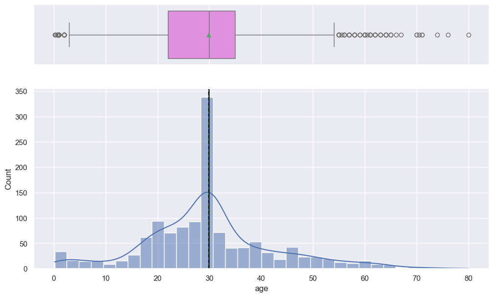

```python
histogram_boxplot(df, 'age', kde=True)
```

```python
df.age.describe()
```

```
count    1309.000000
mean       29.905019
std        12.883281
min         0.170000
25%        22.000000
50%        30.000000
75%        35.000000
max        80.000000
Name: age, dtype: float64
```

The boxplot whisker ends represent the lower and upper limits, given by Q1 - (1.5 * IQR) and Q3 + (1.5 * IQR) respectively. There are outliers on both ends of the age boxplot.

The distribution appears normal, with many passengers at the mean/median range.

- mean = 29.905
- median = 30.0

### **`embarked`**

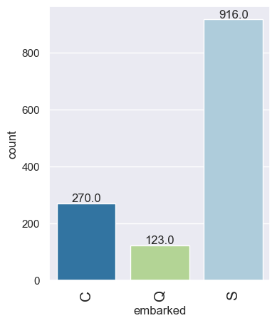

```python
labeled_barplot(df, 'embarked')
```

### **`fare`**

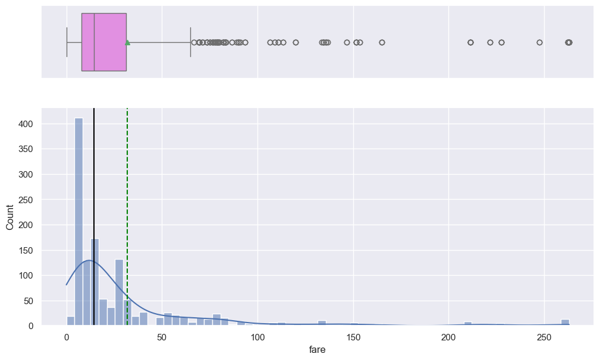

```python
histogram_boxplot(df, 'fare', kde=True)
```

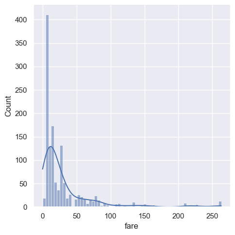

```python
sns.displot(df['fare'], kde=True)
```

```python
df.fare.describe()
```

```
count    1309.000000
mean       31.898873
std        44.448381
min         0.000000
25%         7.895800
50%        14.454200
75%        31.275000
max       263.000000
Name: fare, dtype: float64
```

The **`fare`** distribution appears to be heavily right skewed.

### **`parch`**

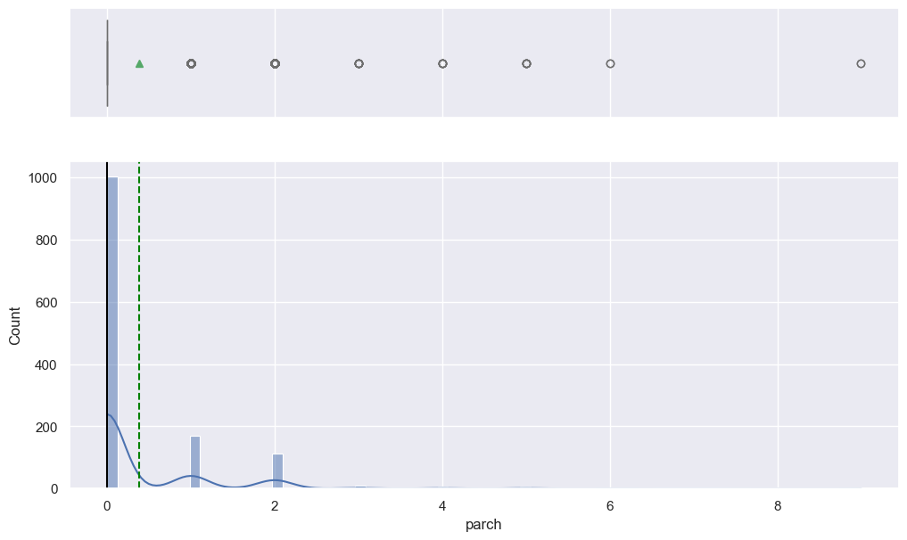

```python
histogram_boxplot(df, 'parch', kde=True)
```

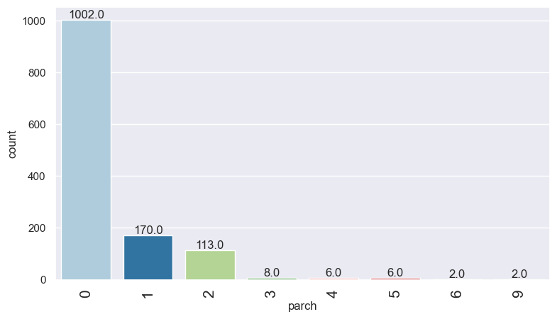

```python
labeled_barplot(df, 'parch')
```

```python
df.parch.describe()
```

```
count    1309.000000
mean        0.385027
std         0.865560
min         0.000000
25%         0.000000
50%         0.000000
75%         0.000000
max         9.000000
Name: parch, dtype: float64
```

### **`pclass`**

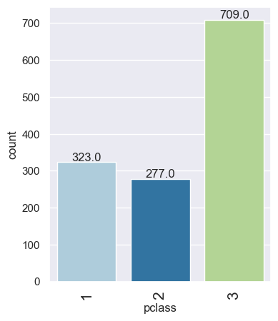

```python
labeled_barplot(df, 'pclass')
```

### **`sex`**

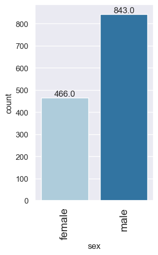

```python
labeled_barplot(df, 'sex')
```

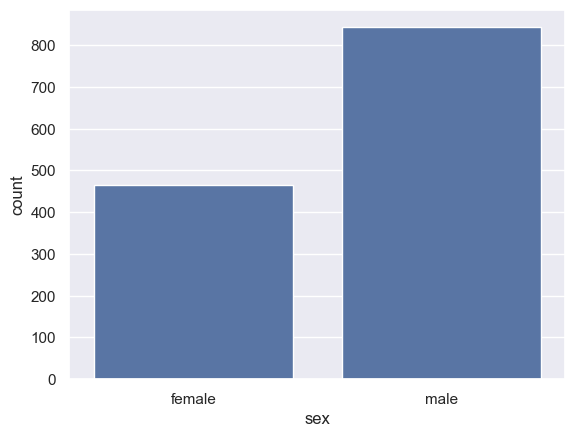

```python
sns.countplot(data=df, x='sex')
```

- Female passengers: ~470
- Male passengers: ~840

### **`sibsp`**

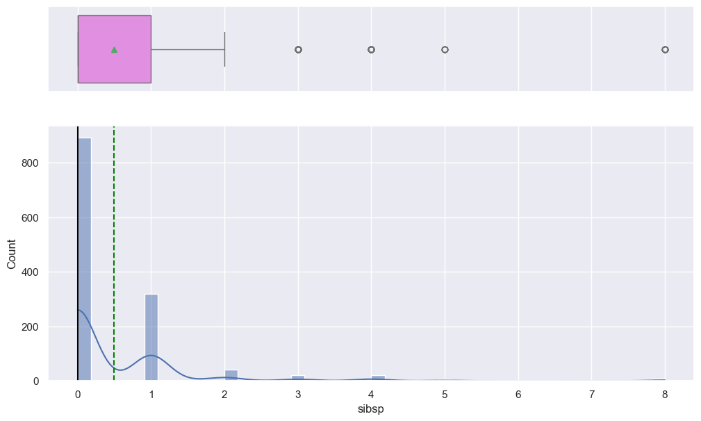

```python
histogram_boxplot(df, 'sibsp', kde=True)
```

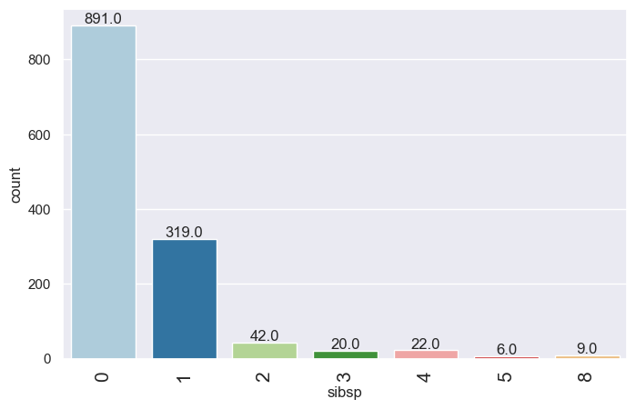

```python
labeled_barplot(df, 'sibsp')
```

```python
df.sibsp.describe()
```

```
count    1309.000000
mean        0.498854
std         1.041658
min         0.000000
25%         0.000000
50%         0.000000
75%         1.000000
max         8.000000
Name: sibsp, dtype: float64
```

### **`survived`**

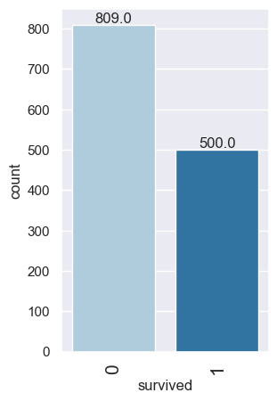

```python
labeled_barplot(df, 'survived')
```

## Multivariate Analysis

```python
pd.crosstab([df.sex,df.survived],df.pclass,margins=True)
```

| sex | pclass survived | 1 | 2 | 3 | All |
| --- | --- | --- | --- | --- | --- |
| female | 0 | 5 | 12 | 110 | 127 |
|  | 1 | 139 | 94 | 106 | 339 |
| male | 0 | 118 | 146 | 418 | 682 |
|  | 1 | 61 | 25 | 75 | 161 |
| All |  | 323 | 277 | 709 | 1309 |

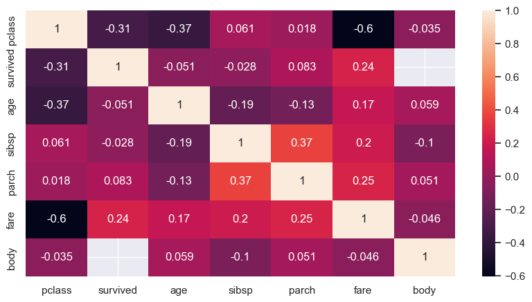

```python
plt.figure(figsize=(10,5))
sns.heatmap(df.corr(numeric_only=True), annot=True)
```

- **`parch`** and **`sibsp`** are the most positively correlated pair
- **`fare`** and **`pclass`** are the most negatively correlated pair

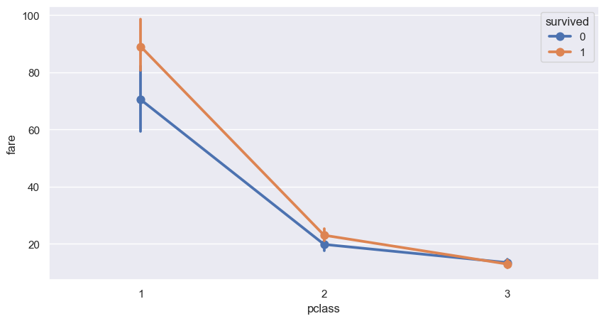

```python
plt.figure(figsize=(10,5))
sns.pointplot(data=df, x='pclass', y='fare', hue='survived')
#sns.pointplot(data=df, x='fare', y='pclass', hue='survived')
#sns.pointplot(data=df, x='fare', y='survived', hue='pclass')
#sns.pointplot(data=df, x='survived', y='pclass', hue='fare')
#sns.pointplot(data=df, x='pclass', y='survived', hue='fare')
#sns.pointplot(data=df, x='survived', y='fare', hue='pclass')
```

The pointplot with x='pclass', y='fare', and hue='survived' appeared to be by far the most informative.

### **`survived`** / **`age`**

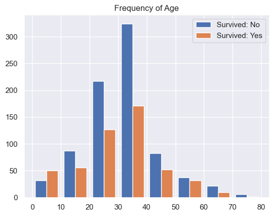

```python
dt0 = df['age'][df['survived']==0]
dt1 = df['age'][df['survived']==1]

bins = np.arange(0, df['age'].max()+10, 10)

plt.hist([dt0,dt1], label=['Survived: No','Survived: Yes'], bins=bins)

plt.legend(loc='upper right')
plt.title('Frequency of Age')
```

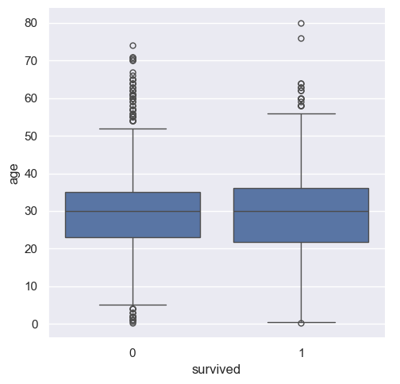

```python
sns.catplot(data=df, x='survived', y='age', kind='box')
```

### **`survived`** / **`embarked`**

```
survived    0    1   All
embarked
All       809  500  1309
S         610  306   916
C         120  150   270
Q          79   44   123
-------------------------------------------------------------------------------------------------------------------
survived         0         1
embarked
C         0.444444  0.555556
Q         0.642276  0.357724
S         0.665939  0.334061
```

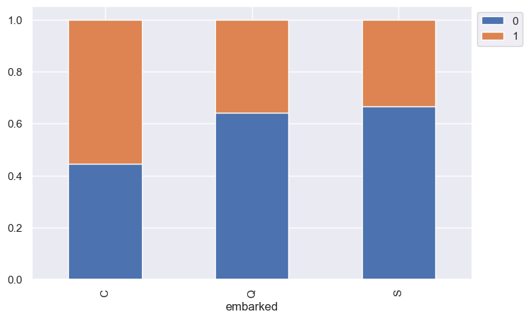

```python
stacked_barplot(df, 'embarked', 'survived')
```

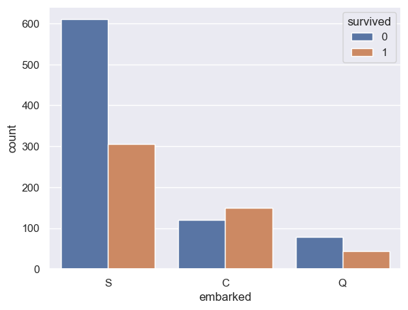

```python
sns.countplot(x='embarked', hue='survived', data=df)
```

### **`survived`** / **`fare`**

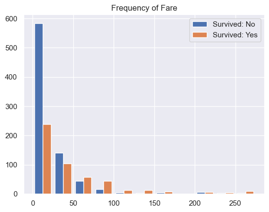

```python
dt0 = df['fare'][df['survived']==0]
dt1 = df['fare'][df['survived']==1]

bins = np.arange(0, df['fare'].max()+25, 25)

plt.hist([dt0,dt1], label=['Survived: No','Survived: Yes'], bins=bins)

plt.legend(loc='upper right')
plt.title('Frequency of Fare')
```

### **`survived`** / **`parch`**

```
survived    0    1   All
parch
All       809  500  1309
0         666  336  1002
1          70  100   170
2          56   57   113
3           3    5     8
4           5    1     6
5           5    1     6
6           2    0     2
9           2    0     2
-------------------------------------------------------------------------------------------------------------------
survived         0         1
parch
3         0.375000  0.625000
1         0.411765  0.588235
2         0.495575  0.504425
0         0.664671  0.335329
4         0.833333  0.166667
5         0.833333  0.166667
6         1.000000  0.000000
9         1.000000  0.000000
```

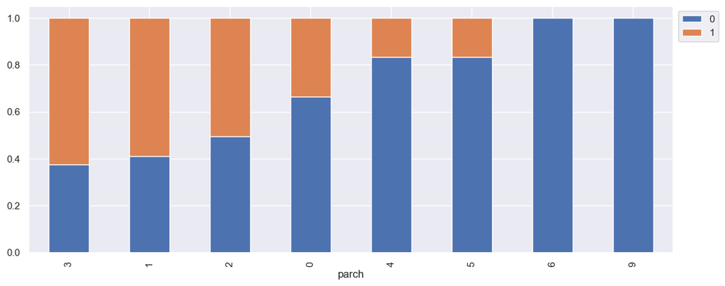

```python
stacked_barplot(df, 'parch', 'survived')
```

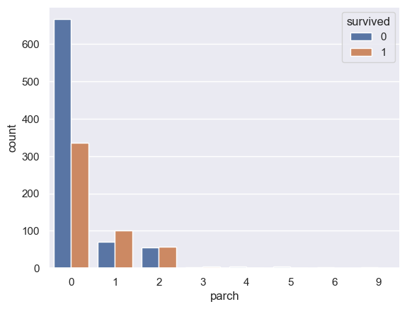

```python
sns.countplot(x='parch', hue='survived', data=df)
```

### **`survived`** / **`pclass`**

```
survived    0    1   All
pclass
All       809  500  1309
1         123  200   323
3         528  181   709
2         158  119   277
-------------------------------------------------------------------------------------------------------------------
survived         0         1
pclass
1         0.380805  0.619195
2         0.570397  0.429603
3         0.744711  0.255289
```

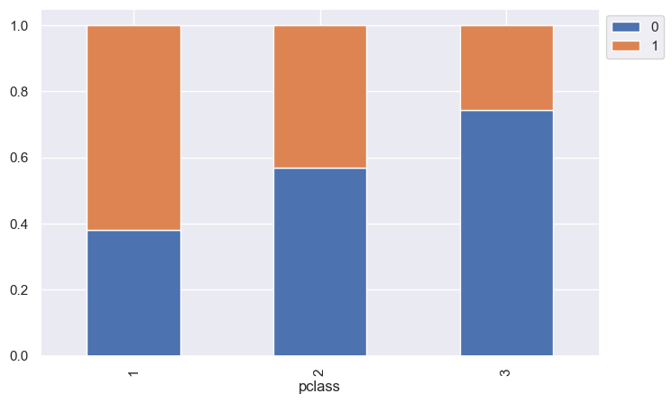

```python
stacked_barplot(df, 'pclass', 'survived')
```

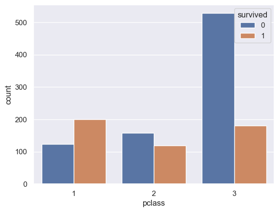

```python
# df.groupby('pclass')['survived'].value_counts()
sns.countplot(data=df, x='pclass', hue='survived')
```

- 1st class: ~200 survivors
- 2nd class: ~120 survivors
- 3rd class: ~180 survivors

### **`survived`** / **`sex`**

```
survived    0    1   All
sex
All       809  500  1309
female    127  339   466
male      682  161   843
-------------------------------------------------------------------------------------------------------------------
survived         0         1
sex
female    0.272532  0.727468
male      0.809015  0.190985
```

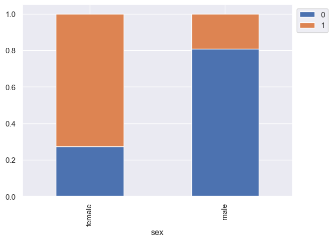

```python
stacked_barplot(df, 'sex', 'survived')
```

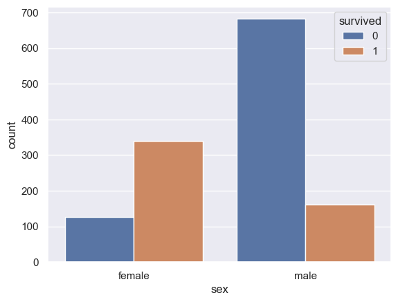

```python
sns.countplot(x='sex', hue='survived', data=df)
```

### **`survived`** / **`sibsp`**

```
survived    0    1   All
sibsp
All       809  500  1309
0         582  309   891
1         156  163   319
2          23   19    42
3          14    6    20
4          19    3    22
5           6    0     6
8           9    0     9
-------------------------------------------------------------------------------------------------------------------
survived         0         1
sibsp
1         0.489028  0.510972
2         0.547619  0.452381
0         0.653199  0.346801
3         0.700000  0.300000
4         0.863636  0.136364
5         1.000000  0.000000
8         1.000000  0.000000
```

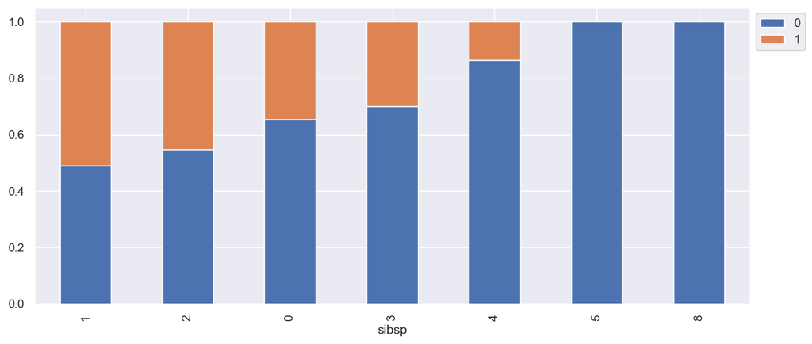

```python
stacked_barplot(df, 'sibsp', 'survived')
```

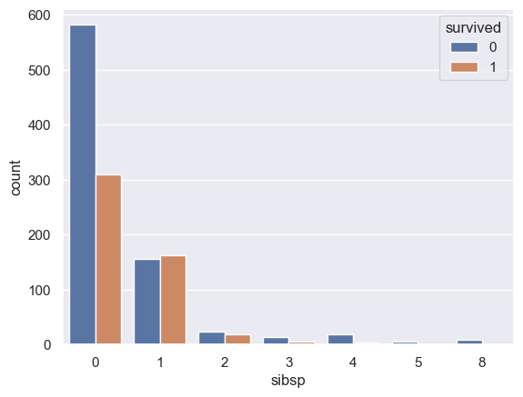

```python
sns.countplot(x='sibsp', hue='survived', data=df)
```